# STA1561-2023 Kuis C

STA1561-2023 Kuis C

```r
library(pracma)
```

## Fungsi `user-defined`

### Fungsi Trapezoidal

```r
trapezoidal <- function(ftn, a, b, n, toleransi = 1e-4, ...){
  res <- data.frame(n=NULL, result=NULL, error=NULL)
  e <- 1

  # get the exact value
  exact <- integrate(ftn, a, b, ...)
  while(e > toleransi){
    # let the trapz calculate begin
    h <- (b-a)/n
    x.vec <- seq(a, b, by=h)
    f.vec <- sapply(x.vec, ftn, ...)
    Z <- h*(f.vec[1]/2 + sum(f.vec[2:n]) + f.vec[n+1]/2)

    # write
    e <- abs(Z-exact$value)
    res <- rbind(res, data.frame(n=n, result=Z, error=e))
    n <- n+1
  }

  res
}
```

### Fungsi Simpson

```r
simpson <- function(ftn, a, b, n, toleransi = 1e-4, ...){
  res <- data.frame(n=NULL, result=NULL, error=NULL)
  e <- 1

  # get the exact value
  exact <- integrate(ftn, a, b, ...)
  while(e > toleransi){
    # let the simpson calculate begin
    n_s <- max(c(2*(n %/% 2), 4))
    h <- (b-a)/n_s

    x.vec1 <- seq(a+h, b-h, by = 2*h) # odd
    x.vec2 <- seq(a+2*h, b-2*h, by = 2*h) # even

    f.vec1 <- sapply(x.vec1, ftn, ...) # odd
    f.vec2 <- sapply(x.vec2, ftn, ...) # even

    S <- h/3*(ftn(a, ...) + ftn(b, ...) + 4*sum(f.vec1) + 2*sum(f.vec2))

    # write
    e <- abs(S-exact$value)
    res <- rbind(res, data.frame(n=n, result=S, error=e))
    n <- n+1
  }

  res
}
```

### Fungsi Gaussian (Adaptive) Quadrature

```r
gaussQuadrature <- function(ftn, a, b, n, toleransi = 1e-4, ...){
  res <- data.frame(n=NULL, result=NULL, error=NULL)
  e <- 1

  # get the exact value
  exact <- integrate(ftn, a, b, ...)
  while(e > toleransi){
    # get gauss point and coefficient
    eval(parse(text=paste0("gL <- gaussLegendre(n, a=", a, ",", b, ")")))

    C_i <- gL$w # koefisien
    x_i <- gL$x # gauss point
    I <- sum(C_i * ftn(x_i, ...))

    # write
    e <- abs(I-exact$value)
    res <- rbind(res, data.frame(n=n, result=I, error=e))
    n <- n+1
  }

  res
}
```

### Fungsi Monte Carlo Integration

```r
monteCarloIntegral <- function(ftn, a, b, m=1000, ...){
  # Generating x distribute U(a,b)
  x <- runif(m, a, b)

  # Evaluate mean from fx
  Gx <- ftn(x, ...)
  Gx_bar <- mean(Gx)

  theta.hat <- (b-a) * Gx_bar

  theta.hat
}
```

### Fungsi Newton-Raphson

```r
newtonraphson <- function(ftn, x0, tol = 1e-5, max.iter = 100) {
  x <- x0
  fx <- ftn(x)
  iter <- 0
  # menyimpan semua hasil
  all_res <- data.frame(
    iteration=iter, x_old=x0, x_new=x, `f(x)`=fx[[1]], error = abs(fx[[1]])
  )

  while ((abs(fx[1]) > tol) && (iter < max.iter)) {
    x0 <- x
    x <- x - fx[1]/fx[2]
    fx <- ftn(x)
    iter <- iter + 1

    #menyimpan semua hasil
    all_res <- rbind(all_res,
      data.frame(
        iteration=iter, x_old=x0, x_new=x, `f(x)`=fx[[1]], error = abs(fx[[1]])
      )
    )
  }

  # output bergantung pada kesuksesan algoritma
  if (abs(fx[1]) > tol) {
    cat("Algorithm failed to converge\n")
    return(list(all_result=all_res,x_roots=NULL))
  } else {
    cat("Algorithm converged\n")
    return(list(all_result=all_res,x_roots=x))
  }
}
```

### Fungsi Secant

```r
secant <- function(ftn, x0, x1, tol = 1e-9, max.iter = 100) {
  xa <- x0
  fxa <- ftn(xa)
  xb <- x1
  fxb <- ftn(xb)
  iter <- 0

  # menyimpan semua hasil
  all_res <- data.frame(
    iteration=iter, xa=x0, xb=x1, `f(x_a)`=fxa, `f(x_b)`=fxb, error = abs(xb-xa)
  )

  while ((abs(xb-xa) > tol) && (iter < max.iter)) {
    xt <- fxb*((xb-xa)/(fxb-fxa))
    xc <- xb-xt

    iter <- iter + 1

    xa <- xb
    xb <- xc
    fxa <- ftn(xa)
    fxb <- ftn(xb)

    # menyimpan semua hasil
    all_res <- rbind(all_res,
      data.frame(
        iteration=iter, xa=xa, xb=xb, `f(x_a)`=fxa, `f(x_b)`=fxb, error = abs(xb-xa)
      )
    )
  }

  if (abs(xb-xa) > tol) {
    cat("Algorithm failed to converge\n")
    return(list(all_result=all_res,x_roots=NULL))
  } else {
    cat("Algorithm converged\n")
    return(list(all_result=all_res,x_roots=xb))
  }
}
```

### Fungsi Bisection

```r
bisection <- function(f, xl, xr, tol = 1e-7,max.iter = 100) {
  # Jika tanda dari hasil perkalian  evaluasi fungsi pada titik xl dan xr bernilai positif (f(xl)*f(xr)>0) maka program dihentikan
  if (f(xl)*f(xr) > 0) {
    stop('signs of f(xl) and f(xr) must be differ')
  }

  # menyimpan semua hasil
  all_res <-data.frame(
    iteration=0, x_left=0, x_right=0, x_mid = 0, `f(xm)`=0, error = 1000
  )

  for (iter in 1:max.iter) {
    xm <- (xl + xr) / 2 # menghitung nilai tengah

    # menyimpan semua hasil
    all_res <-rbind(all_res,
      data.frame(
        iteration=iter, x_left=xl, x_right=xr, x_mid = xm, `f(xm)`=f(xm), error = abs(xr - xl)
      )
    )

    #Jika fungsinya sama dengan 0 di titik tengah atau titik tengah di bawah toleransi yang diinginkan, hentikan dan keluarkan nilai tengah sebagai akar
    if ((f(xm) == 0) || abs(xr - xl) < tol) {
      return(list(all_result=all_res,x_roots=xm))
    }

    # Jika diperlukan iterasi lain,
    # periksa tanda-tanda fungsi pada titik xm dan xl dan tetapkan kembali
    # xl atau xr sebagai titik tengah yang akan digunakan pada iterasi berikutnya.
    ifelse(sign(f(xm)) == sign(f(xl)), xl <- xm,xr <- xm)
  }
}
```

## No. 1

Diketahui fungsi kepekatan peluang dari suatu distribusi berikut

$$f(x; \beta)=5\beta x^4(1-x^5)^{\beta-1},
\space 0<x<1$$

Jika $\beta = 2$

1. [25] Hitunglah $E(X)$ dengan menggunakan metode Trapezoidal, Simpson dengan $n=4$, dan four point Gauss Quadrature.
2. [10] Jika nilai exact $E(X) = \frac{\beta\Gamma(\frac{6}{5})\Gamma(\beta)}{\Gamma(\frac{6}{5}+\beta)}$, metode mana yang paling mendekati untuk menghitung nilai $E(X)$ dengan toleransi $0.0001$?

```r
fx2 <- function(x) {10*x^5*(1-x^5)}
exact_val = integrate(fx2,0,1)
exact_val$value
```

```
## [1] 0.7575758
```

```r
n <- 100
tol <- 0.0001
m <- 100
fx_t <- trapezoidal(fx2, 0, 1, n, tol)
fx_s <- simpson(fx2, 0, 1, n, tol)
fx_g <- gaussQuadrature(fx2, 0, 1, n, tol)
fx_m <- monteCarloIntegral(fx2, 0, 1, m)

# compare
result <- data.frame(result=rbind(tail(fx_t, n=1)$result, tail(fx_s, n=1)$result, tail(fx_g, n=1)$result, fx_m))
comparison <- cbind(method=c('Trapezoidal', 'Simpson', 'Gauss Quadrature', 'Monte Carlo'), result)
row.names(comparison) <- NULL

# comparison$diff <- abs(comparison$result - (4*gamma(1+1/5)*gamma(4) / gamma(1+1/5+4)))
comparison$diff <- abs(comparison$result - exact_val$value)
comparison
```

| method | result | diff |
| --- | --- | --- |
| Trapezoidal | 0.7574766 | 9.914214e-05 |
| Simpson | 0.7575754 | 3.664667e-07 |
| Gauss Quadrature | 0.7575758 | 1.554312e-15 |
| Monte Carlo | 0.7287310 | 2.884472e-02 |

## No. 2

Telusuri algoritme berikut

1. Baca data $x_i(i=1, 2, 3, ..., n)$
2. $i=1$
3. Jika $i \le n-1$, lanjutkan langkah ke 4. Selainnya iterasi berakhir, lalu ke langkah 12
4. Inisialisasi nilai index terkecil $min = i$
5. $j = i+1$
6. Jika $j \le n$, lanjutkan langkah ke 7. Selainnya lanjutkan langkah ke 10
7. Jika $x_j > x_{min}$, lanjutkan langkah ke 8. Selainnya lanjutkan langkah ke 9
8. Ganti nilai index terkecil $min = j$
9. $j = j+1$, lanjutkan langkah ke 6
10. Tukar nilai pada elemen ke $i$ dengan nilai pada elemen dengan index terkecil
11. $i = i+1$, lanjutkan langkah ke 3
12. Cetak $x_i$

[25] *Trace* algoritme di atas jika data $x_i=(9, 8, 11, 2, 4)$, kemudian susun program R yang sesuai dengan algoritme tersebut!

```r
x <- c(9, 8, 11, 2, 4)
xmin <- x
n <- length(x)
for(i in 1:(n-1)){
 for(j in 1:(n-i)) {
   if(xmin[j+1] > xmin[j]) {
   tmp <- xmin[j]
   xmin[j] <- xmin[j+ 1]
   xmin[j+1] <- tmp
   }
 }
}
xmin
```

```
## [1] 11  9  8  4  2
```

## No. 3

[20] Carilah akar persamaan berikut $e^{2x}=x+6$ menggunakan metode Newton-Rhapson, Secant, dan Bisection dengan program R. Gunakan batas $x$ yang menurut Anda tepat untuk digunakan pada metode tersebut agar mencapai kekonvergenan.

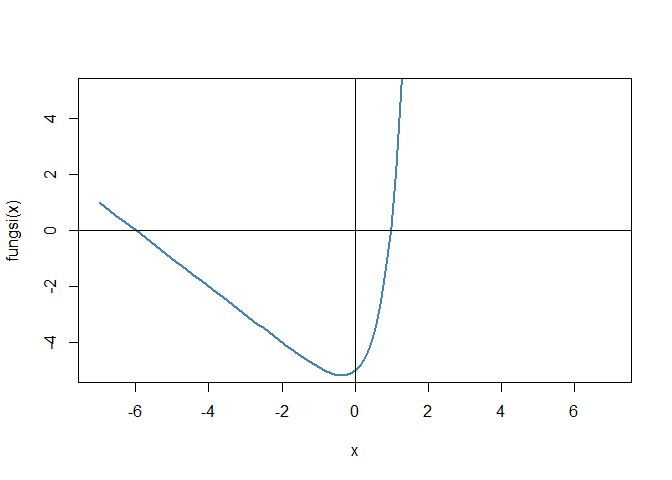

```r
fungsi <- function(x) exp(2*x)-x-6
curve(fungsi, xlim=c(-7,7), ylim=c(-5,5), col='steelblue',lwd=2)
abline(h=0)
abline(v=0)
```

```r
fx_i <- function(x) {
  rumus_fungsi <- function(x) exp(2*x)-x-6
  fungsi <- rumus_fungsi(x)
  # mencari turunan dengan menggunakan fungsi Deriv
  # dari package Deriv
  rumus_turunan <- Deriv::Deriv(rumus_fungsi)
  turunan <- rumus_turunan(x)
  return(c("fungsi"=fungsi,"turunan"=turunan))
}
```

```r
# newton raphson
nr_res <- newtonraphson(ftn=fx_i, x0=-2)
```

```
## Algorithm converged
```

```r
nr_res
```

```
## $all_result
##         iteration     x_old     x_new          f.x.        error
## 1               0 -2.000000 -2.000000 -3.981684e+00 3.981684e+00
## fungsi          1 -2.000000 -6.133085  1.330892e-01 1.330892e-01
## fungsi1         2 -6.133085 -5.999994  1.826387e-07 1.826387e-07
##
## $x_roots
##    fungsi
## -5.999994
```

```r
# secant
sec_res <- secant(fungsi, x0=-1, x1=1)
```

```
## Algorithm converged
```

```r
sec_res
```

```
## $all_result
##   iteration         xa        xb        f.x_a.        f.x_b.        error
## 1         0 -1.0000000 1.0000000 -4.864665e+00  3.890561e-01 2.000000e+00
## 2         1  1.0000000 0.8518931  3.890561e-01 -1.357181e+00 1.481069e-01
## 3         2  0.8518931 0.9670023 -1.357181e+00 -4.984763e-02 1.151091e-01
## 4         3  0.9670023 0.9713913 -4.984763e-02  6.749750e-03 4.389025e-03
## 5         4  0.9713913 0.9708678  6.749750e-03 -2.814647e-05 5.234309e-04
## 6         5  0.9708678 0.9708700 -2.814647e-05 -1.580184e-08 2.173644e-06
## 7         6  0.9708700 0.9708700 -1.580184e-08  3.641532e-14 1.221001e-09
## 8         7  0.9708700 0.9708700  3.641532e-14  8.881784e-16 2.775558e-15
##
## $x_roots
## [1] 0.97087
```

```r
# bisection
bis_res <- bisection(fungsi, xl=-1, xr=1)
bis_res
```

```
## $all_result
##    iteration     x_left   x_right     x_mid         f.xm.        error
## 1          0  0.0000000 0.0000000 0.0000000  0.000000e+00 1.000000e+03
## 2          1 -1.0000000 1.0000000 0.0000000 -5.000000e+00 2.000000e+00
## 3          2  0.0000000 1.0000000 0.5000000 -3.781718e+00 1.000000e+00
## 4          3  0.5000000 1.0000000 0.7500000 -2.268311e+00 5.000000e-01
## 5          4  0.7500000 1.0000000 0.8750000 -1.120397e+00 2.500000e-01
## 6          5  0.8750000 1.0000000 0.9375000 -4.166809e-01 1.250000e-01
## 7          6  0.9375000 1.0000000 0.9687500 -2.737418e-02 6.250000e-02
## 8          7  0.9687500 1.0000000 0.9843750  1.773437e-01 3.125000e-02
## 9          8  0.9687500 0.9843750 0.9765625  7.412408e-02 1.562500e-02
## 10         9  0.9687500 0.9765625 0.9726562  2.316146e-02 7.812500e-03
## 11        10  0.9687500 0.9726562 0.9707031 -2.159527e-03 3.906250e-03
## 12        11  0.9707031 0.9726562 0.9716797  1.048765e-02 1.953125e-03
## 13        12  0.9707031 0.9716797 0.9711914  4.160734e-03 9.765625e-04
```

[output cut: 17 more lines]

## No. 4 (Bonus)

[20] Susunlah sintaks R untuk penjumlahan deret berikut!

$Z = -10 + -6 + 2 + 14 + 30 + 50 + \cdots$

```r
# fa <- function(n)  4*n^2+14*n
deret <- function(i = 0, toleransi = 1e+5){
  i <- 0; z <- 0; e <- 1
  while(e < toleransi){
    zi <- 2*i^2+2*i-10
    z <- z + zi
    i <- i + 1
    e <- abs(zi-z)
  }

  z
}
deret()
```

```
## [1] 110330
```